Pré-Processamento

O objetivo deste documento em formato Rmarkdown é conduzir o pré-processamento da base de dados contida no arquivo kc_house_data.csv. Ao concluir este processo, uma nova versão da base de dados, agora “limpa”, será armazenada em formato CSV. Essa versão tratada será posteriormente utilizada na fase de análise exploratória dos dados e modelagem.

**Faz parte desta etapa:**

- Conversão de formato
- Tratamento de Dados Ausentes
- Tratamento de dados duplicados
- Criação de novas variaveis
- Aprendizado Não Supervisionado de Clusterização
- Tratamento de Outliers

### Bibliotecas

Aqui estão todas as bibliotecas utilizadas neste código.

```r
library(tidyverse)
library(gridExtra)
library(leaflet)
library(corrplot)
library(viridisLite)
library(cluster)
library(knitr)
```

### Base de dados

Importando a base de dados para o ambiente do R:

```r
# Lendo o arquivo csv
df <- read.csv("data/kc_house_data.csv")

# Visualizando as primeiras linhas
rmarkdown::paged_table(head(df))
```

|  | id | date | price | bedrooms | bathrooms | sqft_living | sqft_lot | floors | waterfront | view | condition | grade | sqft_above | sqft_basement | yr_built | yr_renovated | zipcode | lat | long | sqft_living15 | sqft_lot15 |
| --- | --- | --- | --- | --- | --- | --- | --- | --- | --- | --- | --- | --- | --- | --- | --- | --- | --- | --- | --- | --- | --- |
| 1 | 7129300520 | 20141013T000000 | 221900 | 3 | 1.00 | 1180 | 5650 | 1 | 0 | 0 | 3 | 7 | 1180 | 0 | 1955 | 0 | 98178 | 47.5112 | -122.257 | 1340 | 5650 |
| 2 | 6414100192 | 20141209T000000 | 538000 | 3 | 2.25 | 2570 | 7242 | 2 | 0 | 0 | 3 | 7 | 2170 | 400 | 1951 | 1991 | 98125 | 47.7210 | -122.319 | 1690 | 7639 |
| 3 | 5631500400 | 20150225T000000 | 180000 | 2 | 1.00 | 770 | 10000 | 1 | 0 | 0 | 3 | 6 | 770 | 0 | 1933 | 0 | 98028 | 47.7379 | -122.233 | 2720 | 8062 |
| 4 | 2487200875 | 20141209T000000 | 604000 | 4 | 3.00 | 1960 | 5000 | 1 | 0 | 0 | 5 | 7 | 1050 | 910 | 1965 | 0 | 98136 | 47.5208 | -122.393 | 1360 | 5000 |
| 5 | 1954400510 | 20150218T000000 | 510000 | 3 | 2.00 | 1680 | 8080 | 1 | 0 | 0 | 3 | 8 | 1680 | 0 | 1987 | 0 | 98074 | 47.6168 | -122.045 | 1800 | 7503 |
| 6 | 7237550310 | 20140512T000000 | 1225000 | 4 | 4.50 | 5420 | 101930 | 1 | 0 | 0 | 3 | 11 | 3890 | 1530 | 2001 | 0 | 98053 | 47.6561 | -122.005 | 4760 | 101930 |

Número de linhas:

```r
nrow(df)
```

```
## [1] 21613
```

### Valores Nulos

O primeiro tratamento a ser realizado é verificar a quantidade de valores nulos por coluna.

```r
nulos <- as.data.frame(colSums(is.na(df)))
rmarkdown::paged_table(nulos)
```

|  | colSums(is.na(df)) |
| --- | --- |
| id | 0 |
| date | 0 |
| price | 0 |
| bedrooms | 0 |
| bathrooms | 0 |
| sqft_living | 0 |
| sqft_lot | 0 |
| floors | 0 |
| waterfront | 0 |
| view | 0 |

[output cut: 11 more lines]

Não existe nenhuma coluna com valores nulos.

### Ajustando formato

Nesta parte iremos ajustar o formato das colunas.

```r
str(df)
```

```
## 'data.frame':    21613 obs. of  21 variables:
##  $ id           : num  7.13e+09 6.41e+09 5.63e+09 2.49e+09 1.95e+09 ...
##  $ date         : chr  "20141013T000000" "20141209T000000" "20150225T000000" "20141209T000000" ...
##  $ price        : num  221900 538000 180000 604000 510000 ...
##  $ bedrooms     : int  3 3 2 4 3 4 3 3 3 3 ...
##  $ bathrooms    : num  1 2.25 1 3 2 4.5 2.25 1.5 1 2.5 ...
##  $ sqft_living  : int  1180 2570 770 1960 1680 5420 1715 1060 1780 1890 ...
##  $ sqft_lot     : int  5650 7242 10000 5000 8080 101930 6819 9711 7470 6560 ...
##  $ floors       : num  1 2 1 1 1 1 2 1 1 2 ...
##  $ waterfront   : int  0 0 0 0 0 0 0 0 0 0 ...
##  $ view         : int  0 0 0 0 0 0 0 0 0 0 ...
##  $ condition    : int  3 3 3 5 3 3 3 3 3 3 ...
##  $ grade        : int  7 7 6 7 8 11 7 7 7 7 ...
##  $ sqft_above   : int  1180 2170 770 1050 1680 3890 1715 1060 1050 1890 ...
##  $ sqft_basement: int  0 400 0 910 0 1530 0 0 730 0 ...
##  $ yr_built     : int  1955 1951 1933 1965 1987 2001 1995 1963 1960 2003 ...
##  $ yr_renovated : int  0 1991 0 0 0 0 0 0 0 0 ...
##  $ zipcode      : int  98178 98125 98028 98136 98074 98053 98003 98198 98146 98038 ...
##  $ lat          : num  47.5 47.7 47.7 47.5 47.6 ...
##  $ long         : num  -122 -122 -122 -122 -122 ...
##  $ sqft_living15: int  1340 1690 2720 1360 1800 4760 2238 1650 1780 2390 ...
##  $ sqft_lot15   : int  5650 7639 8062 5000 7503 101930 6819 9711 8113 7570 ...
```

A única coluna que necessita de tratamento é a coluna date, que será transformada para formato de data.

Nova classe da coluna date:

```r
# Transformando coluna date em datetime
df$date <- as.Date(df$date, format="%Y%m%dT%H%M%S")

# Visualizando mudança
class(df$date)
```

```
## [1] "Date"
```

### Linhas Duplicadas

Verificando se existem linhas duplicadas no dataframe.

```r
any(duplicated(df))
```

```
## [1] FALSE
```

Não existem linhas duplicadas no dataframe.

Outra verificação é se a coluna id possui valores duplicados.

```r
any(duplicated(df$id))
```

```
## [1] TRUE
```

Existem imóveis duplicados no dataframe.

```r
# Salvando IDs duplicados em um vetor
id_duplicados <- unique(df$id[duplicated(df$id)])

# Criando dataframe com as linhas de IDs duplicados
df_id_duplicados <- df[df$id %in% id_duplicados, ]

rmarkdown::paged_table(head(df_id_duplicados))
```

|  | id | date | price | bedrooms | bathrooms | sqft_living | sqft_lot | floors | waterfront | view | condition | grade | sqft_above | sqft_basement | yr_built | yr_renovated | zipcode | lat | long | sqft_living15 | sqft_lot15 |
| --- | --- | --- | --- | --- | --- | --- | --- | --- | --- | --- | --- | --- | --- | --- | --- | --- | --- | --- | --- | --- | --- |
| 94 | 6021501535 | 2014-07-25 | 430000 | 3 | 1.50 | 1580 | 5000 | 1 | 0 | 0 | 3 | 8 | 1290 | 290 | 1939 | 0 | 98117 | 47.6870 | -122.386 | 1570 | 4500 |
| 95 | 6021501535 | 2014-12-23 | 700000 | 3 | 1.50 | 1580 | 5000 | 1 | 0 | 0 | 3 | 8 | 1290 | 290 | 1939 | 0 | 98117 | 47.6870 | -122.386 | 1570 | 4500 |
| 314 | 4139480200 | 2014-06-18 | 1384000 | 4 | 3.25 | 4290 | 12103 | 1 | 0 | 3 | 3 | 11 | 2690 | 1600 | 1997 | 0 | 98006 | 47.5503 | -122.102 | 3860 | 11244 |
| 315 | 4139480200 | 2014-12-09 | 1400000 | 4 | 3.25 | 4290 | 12103 | 1 | 0 | 3 | 3 | 11 | 2690 | 1600 | 1997 | 0 | 98006 | 47.5503 | -122.102 | 3860 | 11244 |
| 325 | 7520000520 | 2014-09-05 | 232000 | 2 | 1.00 | 1240 | 12092 | 1 | 0 | 0 | 3 | 6 | 960 | 280 | 1922 | 1984 | 98146 | 47.4957 | -122.352 | 1820 | 7460 |
| 326 | 7520000520 | 2015-03-11 | 240500 | 2 | 1.00 | 1240 | 12092 | 1 | 0 | 0 | 3 | 6 | 960 | 280 | 1922 | 1984 | 98146 | 47.4957 | -122.352 | 1820 | 7460 |

Ao analisarmos o resultado das observações com id duplicadas, percebemos que alguns imóveis estão duplicados devido a atualizações nos preços ao longo do tempo. Nestes casos, os imóveis provavelmente foram negociados mais de uma vez durante o período de um ano abrangido pelas informações da base. Como propósito final deste trabalho é realizar a predição dos valores dos imóveis, decidimos manter apenas o preço mais recente, descartando informações de preços antigos associados aos mesmos imóveis.

Verificando a existência de duplicidades após tratamento nas observações desatualizadas:

```r
# Removendo observações duplicadas desatualizadas
df <- df %>%
  group_by(id) %>%
  arrange(desc(date)) %>%
  slice(1)

# Visualizando resultado
any(duplicated(df$id))
```

```
## [1] FALSE
```

### Colunas de Datas

A primeira coluna de data que será modificada é a yr_build, que representa o ano em que a casa foi construída. Para realizar essa alteração, faremos a operação na coluna date, subtraindo a coluna yr_build. Isso nos proporcionará a idade do imóvel. Essa modificação oferece uma abordagem mais intuitiva e interpretável ao comparar com o ano de construção.

```r
# Criando coluna com o ano
df$date_year <- format(df$date, "%Y")

# Formatando coluna para int
df$date_year <- as.integer(df$date_year)

# Cálculando a idade do imóvel
df$age <- df$date_year - df$yr_built

# Removendo colunas date_year e yr_built
df$date_year <- NULL
df$yr_built <- NULL

# Visualizando o resultado
rmarkdown::paged_table(head(df))
```

| id | date | price | bedrooms | bathrooms | sqft_living | sqft_lot | floors | waterfront | view | condition | grade | sqft_above | sqft_basement | yr_renovated | zipcode | lat | long | sqft_living15 | sqft_lot15 | age |
| --- | --- | --- | --- | --- | --- | --- | --- | --- | --- | --- | --- | --- | --- | --- | --- | --- | --- | --- | --- | --- |
| 1000102 | 2015-04-22 | 300000 | 6 | 3.00 | 2400 | 9373 | 2.0 | 0 | 0 | 3 | 7 | 2400 | 0 | 0 | 98002 | 47.3262 | -122.214 | 2060 | 7316 | 24 |
| 1200019 | 2014-05-08 | 647500 | 4 | 1.75 | 2060 | 26036 | 1.0 | 0 | 0 | 4 | 8 | 1160 | 900 | 0 | 98166 | 47.4444 | -122.351 | 2590 | 21891 | 67 |
| 1200021 | 2014-08-11 | 400000 | 3 | 1.00 | 1460 | 43000 | 1.0 | 0 | 0 | 3 | 7 | 1460 | 0 | 0 | 98166 | 47.4434 | -122.347 | 2250 | 20023 | 62 |
| 2800031 | 2015-04-01 | 235000 | 3 | 1.00 | 1430 | 7599 | 1.5 | 0 | 0 | 4 | 6 | 1010 | 420 | 0 | 98168 | 47.4783 | -122.265 | 1290 | 10320 | 85 |
| 3600057 | 2015-03-19 | 402500 | 4 | 2.00 | 1650 | 3504 | 1.0 | 0 | 0 | 3 | 7 | 760 | 890 | 2013 | 98144 | 47.5803 | -122.294 | 1480 | 3504 | 64 |
| 3600072 | 2015-03-30 | 680000 | 4 | 2.75 | 2220 | 5310 | 1.0 | 0 | 0 | 5 | 7 | 1170 | 1050 | 0 | 98144 | 47.5801 | -122.294 | 1540 | 4200 | 64 |

Observando a quantidade de linhas não zeradas da coluna yr_renovated

```r
# Cálculando porcentagem de linhas com valores diferentes de zero
(nrow(df[df$yr_renovated != 0, ])/nrow(df))*100
```

```
## [1] 4.245195
```

Considerando que apenas cerca de 4% das observações apresentam valores não nulos na coluna yr_renovated, decidimos transformar essa coluna em uma variável binária. Essa variável indicará se o imóvel foi (1) ou não (0) renovado. Essa abordagem simplifica a informação, tornando-a mais relevante para análises e modelagem subsequentes. Além disso, contribui para a eficácia e interpretabilidade do conjunto de dados, facilitando sua interpretação.

```r
# Criando coluna binaria
df$renovated <- ifelse(df$yr_renovated == 0, 0, 1)

# Retirando coluna yr_renovated do dataframe
df$yr_renovated <- NULL

# Visualizando os resultados
rmarkdown::paged_table(head(df))
```

| id | date | price | bedrooms | bathrooms | sqft_living | sqft_lot | floors | waterfront | view | condition | grade | sqft_above | sqft_basement | zipcode | lat | long | sqft_living15 | sqft_lot15 | age | renovated |
| --- | --- | --- | --- | --- | --- | --- | --- | --- | --- | --- | --- | --- | --- | --- | --- | --- | --- | --- | --- | --- |
| 1000102 | 2015-04-22 | 300000 | 6 | 3.00 | 2400 | 9373 | 2.0 | 0 | 0 | 3 | 7 | 2400 | 0 | 98002 | 47.3262 | -122.214 | 2060 | 7316 | 24 | 0 |
| 1200019 | 2014-05-08 | 647500 | 4 | 1.75 | 2060 | 26036 | 1.0 | 0 | 0 | 4 | 8 | 1160 | 900 | 98166 | 47.4444 | -122.351 | 2590 | 21891 | 67 | 0 |
| 1200021 | 2014-08-11 | 400000 | 3 | 1.00 | 1460 | 43000 | 1.0 | 0 | 0 | 3 | 7 | 1460 | 0 | 98166 | 47.4434 | -122.347 | 2250 | 20023 | 62 | 0 |
| 2800031 | 2015-04-01 | 235000 | 3 | 1.00 | 1430 | 7599 | 1.5 | 0 | 0 | 4 | 6 | 1010 | 420 | 98168 | 47.4783 | -122.265 | 1290 | 10320 | 85 | 0 |
| 3600057 | 2015-03-19 | 402500 | 4 | 2.00 | 1650 | 3504 | 1.0 | 0 | 0 | 3 | 7 | 760 | 890 | 98144 | 47.5803 | -122.294 | 1480 | 3504 | 64 | 1 |
| 3600072 | 2015-03-30 | 680000 | 4 | 2.75 | 2220 | 5310 | 1.0 | 0 | 0 | 5 | 7 | 1170 | 1050 | 98144 | 47.5801 | -122.294 | 1540 | 4200 | 64 | 0 |

Com essas transformações podemos retirar a coluna de data do dataframe.

```r
df$date <- NULL
```

E com isso temos as seguintes colunas representando informações temporais dentro da base de dados:

- age: Idade do imóvel;
- renovated: (1) se o imóvel foi renovado em algum momento e (0) se não foi.

### Variaveis do tamanho do apartamento

- sqft_living: Metragem quadrada da área habitável da casa;
- sqft_lot: Metragem quadrada do terreno em pés;
- sqft_above:Metragem quadrada da casa excluindo o porão em pés;
- sqft_basement: Metragem quadrada do porão em pés.
- sqft_living15: Área hábitavel em 2015 (implica algumas reformas). Isso pode ou não ter afetado a metragem do terreno;
- sqft_lot15: Área do terreno em 2015 (implica algumas reformas). Isso pode ou não ter afetado a metragem do terreno;

Primeiramente iremos analisar o quanto essas variaveis se relacionam através de uma matriz de correlação:

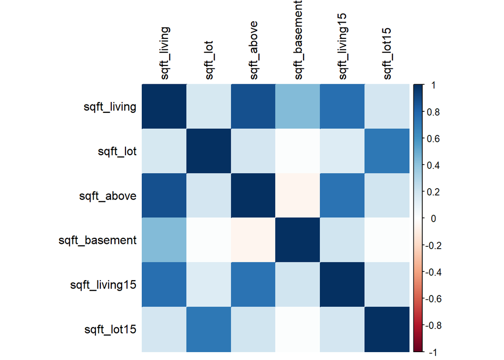

```r
# Calculando correlações
sqft_corr_matrix <- cor(df[, c("sqft_living", "sqft_lot", "sqft_above", "sqft_basement", "sqft_living15", "sqft_lot15")])

# Plot the correlation matrix
corrplot(sqft_corr_matrix, method = "color",tl.col = "black")
```

```r
matrix <- as.data.frame(sqft_corr_matrix)
rmarkdown::paged_table(head(matrix))
```

|  | sqft_living | sqft_lot | sqft_above | sqft_basement | sqft_living15 | sqft_lot15 |
| --- | --- | --- | --- | --- | --- | --- |
| sqft_living | 1.0000000 | 0.1719569 | 0.87668302 | 0.43441925 | 0.7562053 | 0.18277545 |
| sqft_lot | 0.1719569 | 1.0000000 | 0.18258077 | 0.01510740 | 0.1436503 | 0.71809705 |
| sqft_above | 0.8766830 | 0.1825808 | 1.00000000 | -0.05245558 | 0.7319917 | 0.19341330 |
| sqft_basement | 0.4344192 | 0.0151074 | -0.05245558 | 1.00000000 | 0.1992470 | 0.01728315 |
| sqft_living15 | 0.7562053 | 0.1436503 | 0.73199166 | 0.19924702 | 1.0000000 | 0.18244090 |
| sqft_lot15 | 0.1827755 | 0.7180970 | 0.19341330 | 0.01728315 | 0.1824409 | 1.00000000 |

A primeira observação refere-se às variáveis sqft_living15 e sqft_lot15, que apresentam uma alta correlação com as variáveis sqft_living e sqft_lot, respectivamente. Isso é compreensível, uma vez que essas colunas representam possíveis alterações nas dimensões consideradas para a área habitável e o tamanho do lote. No entanto, vale destacar que essas alterações não ocorrem em todas as residências do conjunto de dados e não contribuem significativamente com informações novas que possam aprimorar a precisão das previsões ou a interpretabilidade do modelo, dessa forma, optaremos por excluí-las da análise

```r
df$sqft_living15 <- NULL
df$sqft_lot15 <- NULL
```

Outra correlação significativa identificada ocorre entre as variáveis preditoras sqft_above e sqft_basement com a variável sqft_living. Inicialmente, essa correlação parece ser resultado da soma dessas preditoras, que provavelmente representa a área habitável total. Diante dessa observação, iremos investigar se, de fato, a soma de sqft_above e sqft_basement é equivalente a sqft_living.

```r
# Criando coluna de comparação
df$soma_sqft <- df$sqft_above + df$sqft_basement

# Verificando se há diferenças
dif_sqft <- sum(df$soma_sqft != df$sqft_living)

# Criando teste lógico
if (dif_sqft == 0) {
  print("A soma de sqft_above e sqft_basement é igual a sqft_living para todas as observações.")
} else {
  print("Existem diferenças na soma de sqft_above e sqft_basement em relação a sqft_living.")
}
```

```
## [1] "A soma de sqft_above e sqft_basement é igual a sqft_living para todas as observações."
```

```r
# Retirando coluna do dataframe
df$soma_sqft <- NULL
```

De fato a coluna sqft_living é a soma das variáveis sqft_above e sqft_basement. Em outras palavras, essas variáveis são redundantes e possuem uma relação linear perfeita entre elas. Diante desse entendimento, optaremos por desconsiderar uma das colunas e trabalhar com a porcentagem da área quadrada que o porão representa em relação à metragem habitável total da casa. Essa abordagem simplifica a representação da informação, evitando multicolinearidade e fornecendo uma métrica mais específica para análises futuras.

```r
# Obtendo porcentagem de área com porão
df$basement_percent <- df$sqft_basement/df$sqft_living

# Retirando as colunas sqft_basement e sqft_above do dataframe
df$sqft_above <- NULL
df$sqft_basement <- NULL

# Visualizando o resultado
rmarkdown::paged_table(head(df))
```

| id | price | bedrooms | bathrooms | sqft_living | sqft_lot | floors | waterfront | view | condition | grade | zipcode | lat | long | age | renovated | basement_percent |
| --- | --- | --- | --- | --- | --- | --- | --- | --- | --- | --- | --- | --- | --- | --- | --- | --- |
| 1000102 | 300000 | 6 | 3.00 | 2400 | 9373 | 2.0 | 0 | 0 | 3 | 7 | 98002 | 47.3262 | -122.214 | 24 | 0 | 0.0000000 |
| 1200019 | 647500 | 4 | 1.75 | 2060 | 26036 | 1.0 | 0 | 0 | 4 | 8 | 98166 | 47.4444 | -122.351 | 67 | 0 | 0.4368932 |
| 1200021 | 400000 | 3 | 1.00 | 1460 | 43000 | 1.0 | 0 | 0 | 3 | 7 | 98166 | 47.4434 | -122.347 | 62 | 0 | 0.0000000 |
| 2800031 | 235000 | 3 | 1.00 | 1430 | 7599 | 1.5 | 0 | 0 | 4 | 6 | 98168 | 47.4783 | -122.265 | 85 | 0 | 0.2937063 |
| 3600057 | 402500 | 4 | 2.00 | 1650 | 3504 | 1.0 | 0 | 0 | 3 | 7 | 98144 | 47.5803 | -122.294 | 64 | 1 | 0.5393939 |
| 3600072 | 680000 | 4 | 2.75 | 2220 | 5310 | 1.0 | 0 | 0 | 5 | 7 | 98144 | 47.5801 | -122.294 | 64 | 0 | 0.4729730 |

Observando a distribuição desta nova variavel criada.

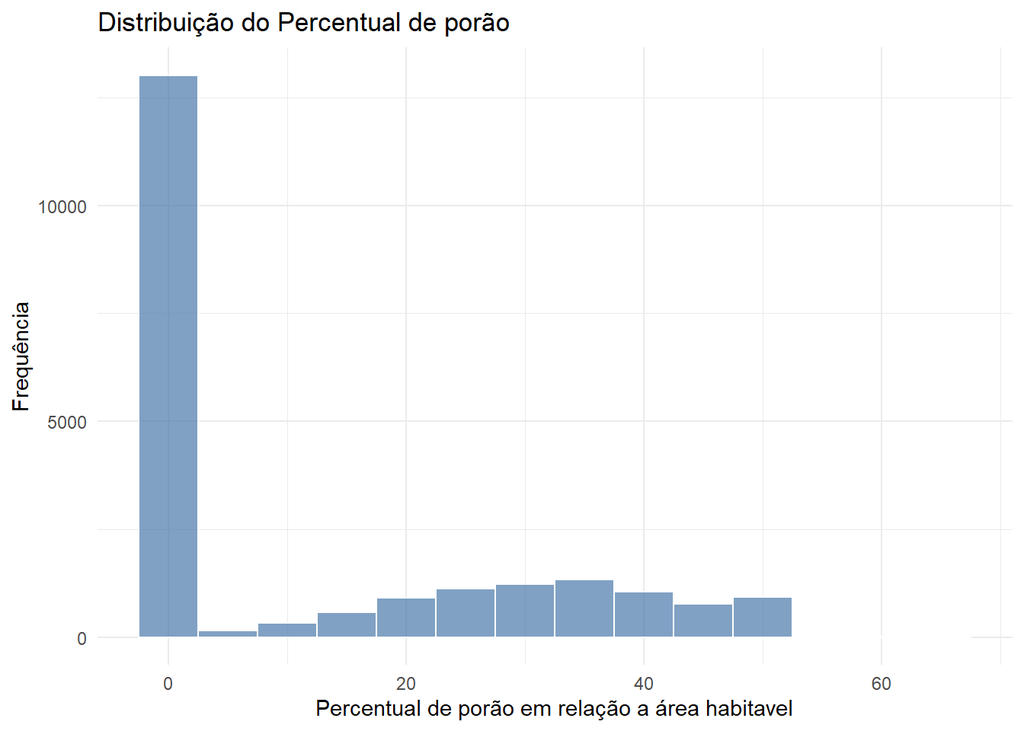

```r
ggplot(df, aes(x = basement_percent*100)) +
  geom_histogram(binwidth = 5, fill = "#4979A9", color = "white", alpha = 0.7) +
  labs(title = "Distribuição do Percentual de porão",
       x = "Percentual de porão em relação a área habitavel",
       y = "Frequência") +
  theme_minimal()
```

Como podemos observar, temos muitas casas que não possuem porão.

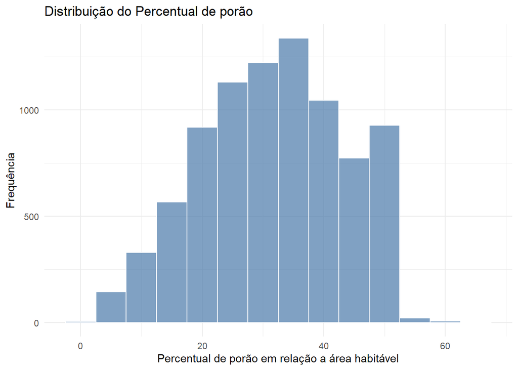

```r
ggplot(df[df$basement_percent > 0, ], aes(x = basement_percent * 100)) +
  geom_histogram(binwidth = 5, fill = "#4979A9", color = "white", alpha = 0.7) +
  labs(title = "Distribuição do Percentual de porão",
       x = "Percentual de porão em relação a área habitável",
       y = "Frequência") +
  theme_minimal()
```

Considerando que a principal métrica no mercado imobiliário para determinar o tamanho dos imóveis é a área construída, escolheremos abordar a coluna sqft_lot, que indica o tamanho total do lote, de maneira proporcional através da razão entre ela e a coluna sqft_living. Dessa forma, obteremos uma medida proporcional do tamanho da área construída em relação ao tamanho total do lote.

```r
# Criando nova métrica
df$living_percent <- df$sqft_living / df$sqft_lot

# Retirando coluna do dataframe
df$sqft_lot <- NULL

# Visualizando dataframe
rmarkdown::paged_table(head(df))
```

| id | price | bedrooms | bathrooms | sqft_living | floors | waterfront | view | condition | grade | zipcode | lat | long | age | renovated | basement_percent | living_percent |
| --- | --- | --- | --- | --- | --- | --- | --- | --- | --- | --- | --- | --- | --- | --- | --- | --- |
| 1000102 | 300000 | 6 | 3.00 | 2400 | 2.0 | 0 | 0 | 3 | 7 | 98002 | 47.3262 | -122.214 | 24 | 0 | 0.0000000 | 0.25605462 |
| 1200019 | 647500 | 4 | 1.75 | 2060 | 1.0 | 0 | 0 | 4 | 8 | 98166 | 47.4444 | -122.351 | 67 | 0 | 0.4368932 | 0.07912122 |
| 1200021 | 400000 | 3 | 1.00 | 1460 | 1.0 | 0 | 0 | 3 | 7 | 98166 | 47.4434 | -122.347 | 62 | 0 | 0.0000000 | 0.03395349 |
| 2800031 | 235000 | 3 | 1.00 | 1430 | 1.5 | 0 | 0 | 4 | 6 | 98168 | 47.4783 | -122.265 | 85 | 0 | 0.2937063 | 0.18818266 |
| 3600057 | 402500 | 4 | 2.00 | 1650 | 1.0 | 0 | 0 | 3 | 7 | 98144 | 47.5803 | -122.294 | 64 | 1 | 0.5393939 | 0.47089041 |
| 3600072 | 680000 | 4 | 2.75 | 2220 | 1.0 | 0 | 0 | 5 | 7 | 98144 | 47.5801 | -122.294 | 64 | 0 | 0.4729730 | 0.41807910 |

Visualizando a distribuição desta nova variavel:

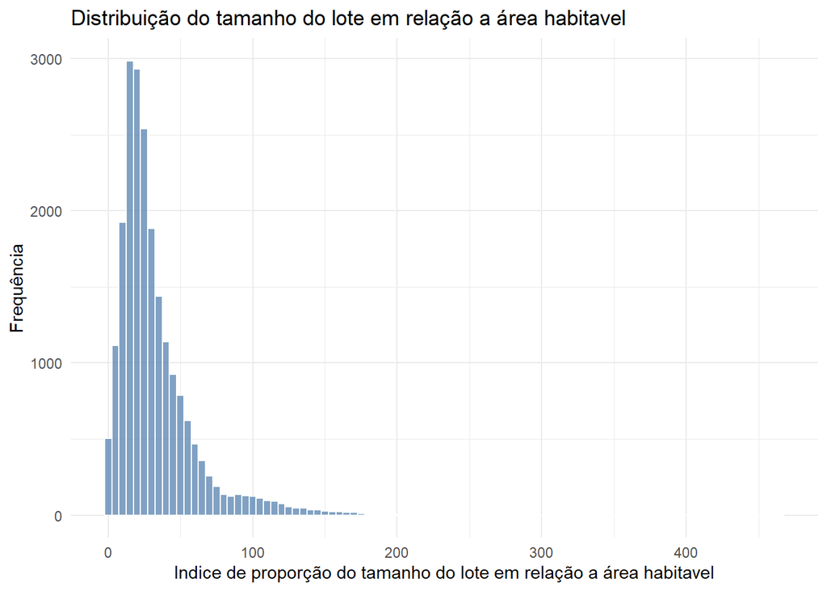

```r
ggplot(df, aes(x = living_percent*100)) +
  geom_histogram(binwidth = 5, fill = "#4979A9", color = "white", alpha = 0.7) +
  labs(title = "Distribuição do tamanho do lote em relação a área habitavel",
       x = "Indice de proporção do tamanho do lote em relação a área habitavel",
       y = "Frequência") +
  theme_minimal()
```

Ao analisar o histograma dessa nova variável, é possível observar que alguns imóveis apresentam valores superiores a 100%, indicando uma área construída maior do que a área total do lote. Essa situação pode parecer inicialmente contraditória. No entanto, esse fenômeno ocorre em situações em que o imóvel possui mais de um andar, o que faz com que a área construída possa ultrapassar o tamanho do lote.

Com isso chegamos nas seguintes váriavel preditoras que representam o tamanho do imóvel:

- sqft_living: Tamanho de área hábitavel(construida) em pés;
- basement_percent: Porcentagem de área construida que representa o porão;
- living_percent: Porcentagem de área de construida em relação ao tamanho total do terreno.

### Preditoras de Localização

Neste dataframe, encontramos três colunas que denotam a localização do apartamento na cidade: zipcode, latitude e longitude. Com o intuito de privilegiar a interpretabilidade do modelo, buscaremos consolidar essas informações de localização em uma única variável. Essa nova variável representará a classe de localização na qual o imóvel se enquadra. Dado que temos informações sobre apartamentos de diversos intervalos de preço e tamanhos, optaremos por utilizar a métrica de preço por feet quadrado para agrupar essas unidades com base na localização. Essa abordagem proporcionará uma representação mais simplificada e compreensível da informação de localização, contribuindo para a eficácia e interpretabilidade do modelo.

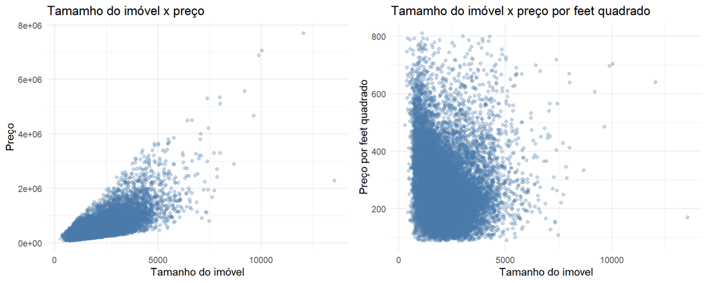

```r
# Criando métrica
df$price_sqft <- df$price / df$sqft_living

# Observando a normalização com relação ao preço
grafico1 <- ggplot(df, aes(x = sqft_living, y = price)) +
  geom_point(color = "#4979A9", alpha = 0.3) +
  labs(title = "Tamamho do imóvel x preço",
       x = "Tamanho do imóvel",
       y = "Preço") +
  theme_minimal()

grafico2<- ggplot(df, aes(x = sqft_living, y = price_sqft)) +
  geom_point(color = "#4979A9", alpha = 0.3) +
  labs(title = "Tamamho do imóvel x preço por feet quadrado",
       x = "Tamanho do imovel",
       y = "Preço por feet quadrado") +
  theme_minimal()

# Plotando
grid.arrange(grafico1, grafico2, ncol = 2)
```

Como pode ser observado, ao utilizar esta nova métrica, não temos mais uma relação linear com o tamanho.

```r
# Paleta
paleta2 <- c("#FFFFCC", "#FED976", "#FEB24C", "#FD8D3C", "#FC4E2A", "#E31A1C", "#BD0026")

# Ajuste a escala de cores conforme necessário
cor_escala <- colorNumeric(palette = paleta2 , domain = df$price_sqft)

# Determine o ponto central do mapa (usando a mediana das coordenadas)
centro_latitude <- median(df$lat)
centro_longitude <- median(df$long)

# Crie um mapa e defina o ponto central e o zoom inicial
map_leaflet <- leaflet(df) %>%
  addTiles() %>%
  setView(lng = centro_longitude, lat = centro_latitude, zoom = 11)

# Adicione marcadores para representar cada ponto de dados
map_leaflet <- map_leaflet %>%
  addCircleMarkers(lng = ~long, lat = ~lat,
                   radius = 2,  # Ajuste o tamanho dos marcadores conforme necessário
                   color = ~cor_escala(price_sqft),
                   fillOpacity = 0.2,
                   popup = ~paste("Preço por m²: $", price_sqft))

# Exiba o mapa
map_leaflet
```

[interactive chart not shown]

Conforme evidenciado no mapa acima, uma região central se destaca, caracterizada por uma tendência de preços por pé quadrado mais elevados. À medida que os imóveis se afastam dessa região central, observa-se uma aparente diminuição nos preços. Demonstrando que localização do imóvel tem influencia no preço.

### Clusterização com K-means

Dado que o propósito deste projeto é não apenas realizar previsões, mas também proporcionar uma interpretação mais aprofundada sobre como cada variável influencia nos resultados preditivos, optaremos por uma abordagem distinta em relação à mera consideração das coordenadas de latitude e longitude de cada imóvel. Utilizaremos o algoritmo não supervisionado k-means para agrupar os zipcodes com características semelhantes de preço por metragem quadrada e localização geográfica.

```r
# Encontrar a quantidade de zipcodes distintos
quantidade_zipcodes_distintos <- length(unique(df$zipcode))

# Imprimir o resultado
cat("Quantidade de zipcodes distintos:", quantidade_zipcodes_distintos, "\n")
```

```
## Quantidade de zipcodes distintos: 70
```

Identificamos a presença de 70 códigos postais distintos neste conjunto de dados, o que pode representar um desafio durante a interpretação dos resultados do modelo. Isso se deve ao fato de que seria necessário criar 69 novas colunas de variáveis dummy para incorporar essas informações, o que pode complicar a análise. Diante desse cenário, parece sensato reclassificar essas localizações utilizando um algoritmo de clusterização.

```r
# Colunas de informação
col_mean <- c("lat", "long", "price_sqft")


# Criando df com informações médias de cada zipcode
df_zipcode <- df %>%
  group_by(zipcode) %>%
  summarise(across(all_of(col_mean), mean))

# Exibindo
rmarkdown::paged_table(head(df_zipcode))
```

| zipcode | lat | long | price_sqft |
| --- | --- | --- | --- |
| 98001 | 47.30903 | -122.2706 | 151.6706 |
| 98002 | 47.30879 | -122.2133 | 151.4269 |
| 98003 | 47.31561 | -122.3101 | 157.8793 |
| 98004 | 47.61607 | -122.2051 | 475.0755 |
| 98005 | 47.61153 | -122.1673 | 314.9292 |
| 98006 | 47.55804 | -122.1469 | 299.0700 |

Com as informações agrupadas por zipcodes, podemos encontrar o número ótimo de clusters de imóveis com caracteristicas parecidas.

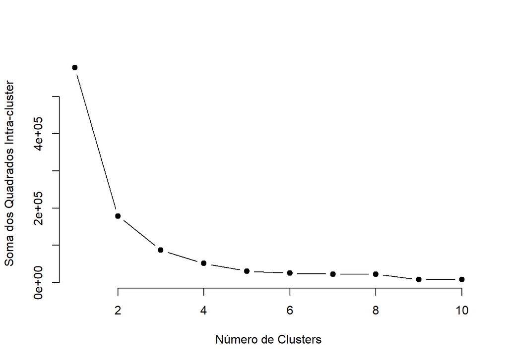

```r
# Calcular a soma dos quadrados intra-cluster para diferentes números de clusters
soma_quadrados <- numeric(10)  # Ajuste o número máximo de clusters conforme necessário

for (k in 1:10) {
  kmeans_result <- kmeans(df_zipcode[-1], centers = k)
  soma_quadrados[k] <- kmeans_result$tot.withinss
}

# Plotar o gráfico do método do cotovelo
plot(1:10, soma_quadrados, type = "b", pch = 19, frame = FALSE,
     xlab = "Número de Clusters", ylab = "Soma dos Quadrados Intra-cluster")
```

Observando o gráfico de cotovelo, o número ótimo de cluster seriam 4 grupos distintos.

```r
# Setando semente aleatória
set.seed(39)

# Executar o algoritmo k-means com 4 clusters
numero_clusters <- 4
kmeans_result <- kmeans(df_zipcode[,-1], centers = numero_clusters)

# Adicionar a coluna 'grupo' ao data frame original indicando o cluster de cada zipcode
df_zipcode$grupo <- as.factor(kmeans_result$cluster)

# Visualizando
rmarkdown::paged_table(head(df_zipcode))
```

| zipcode | lat | long | price_sqft | grupo |
| --- | --- | --- | --- | --- |
| 98001 | 47.30903 | -122.2706 | 151.6706 | 4 |
| 98002 | 47.30879 | -122.2133 | 151.4269 | 4 |
| 98003 | 47.31561 | -122.3101 | 157.8793 | 4 |
| 98004 | 47.61607 | -122.2051 | 475.0755 | 3 |
| 98005 | 47.61153 | -122.1673 | 314.9292 | 2 |
| 98006 | 47.55804 | -122.1469 | 299.0700 | 2 |

Agora que temos os zipcodes separados em 4 grupos de acordo com as caracteristicas médias de cada região, podemos adicionar esta nova preditora para o dataframe original.

```r
# Realizando um leftjoin como dataframe original
df <- merge(df, df_zipcode[, c("zipcode", "grupo")], by = "zipcode", all.x = TRUE)

# Visualizando o resultado
rmarkdown::paged_table(head(df))
```

|  | zipcode | id | price | bedrooms | bathrooms | sqft_living | floors | waterfront | view | condition | grade | lat | long | age | renovated | basement_percent | living_percent | price_sqft | grupo |
| --- | --- | --- | --- | --- | --- | --- | --- | --- | --- | --- | --- | --- | --- | --- | --- | --- | --- | --- | --- |
| 1 | 98001 | 321049127 | 277500 | 3 | 2.25 | 1820 | 1 | 0 | 0 | 4 | 7 | 47.3310 | -122.286 | 50 | 0 | 0.0000000 | 0.09284767 | 152.4725 | 4 |
| 2 | 98001 | 2616700560 | 250000 | 3 | 2.00 | 1660 | 1 | 0 | 0 | 3 | 7 | 47.3298 | -122.277 | 29 | 0 | 0.3915663 | 0.12686282 | 150.6024 | 4 |
| 3 | 98001 | 8961950250 | 384000 | 5 | 2.75 | 3220 | 2 | 0 | 0 | 3 | 9 | 47.3154 | -122.254 | 15 | 0 | 0.0000000 | 0.39460784 | 119.2547 | 4 |
| 4 | 98001 | 2460500020 | 305000 | 4 | 1.75 | 2370 | 1 | 0 | 0 | 3 | 7 | 47.3352 | -122.278 | 47 | 0 | 0.3839662 | 0.23372781 | 128.6920 | 4 |
| 5 | 98001 | 3876600120 | 265000 | 3 | 1.50 | 1780 | 1 | 0 | 0 | 4 | 7 | 47.3375 | -122.291 | 48 | 0 | 0.2865169 | 0.17457827 | 148.8764 | 4 |
| 6 | 98001 | 321049090 | 254000 | 5 | 2.00 | 2080 | 1 | 0 | 0 | 5 | 7 | 47.3424 | -122.289 | 55 | 0 | 0.1634615 | 0.12905628 | 122.1154 | 4 |

Obtendo ordem de sqft_price de cada grupo encontrado.

```r
# Agrupando
group_sqft_price_mean <- df %>%
  group_by(grupo) %>%
  summarise(mean_price_sqft = mean(price_sqft))

# Visualizando
rmarkdown::paged_table(head(group_sqft_price_mean))
```

| grupo | mean_price_sqft |
| --- | --- |
| 1 | 230.5629 |
| 2 | 291.5308 |
| 3 | 392.1130 |
| 4 | 166.7552 |

Com isso temos as seguintes categorias de localização:

- grupo3 = classe A
- grupo2 = classe B
- grupo1 = classe C
- grupo4 = classe D

```r
df$grupo <- ifelse(df$grupo == 1, "C",
                 ifelse(df$grupo == 2, "B",
                        ifelse(df$grupo == 3, "A", "D")))
```

Visualizando no mapa essa nova classificação.

```r
# criando coluna de cor
df$cor <- ifelse(df$grupo == "A", "#E41A1C",
                 ifelse(df$grupo == "B", "#377EB8",
                        ifelse(df$grupo == "C", "#4DAF4A", "#984EA3")))

# Criar o mapa
mapa <- leaflet(df) %>%
  addTiles() %>%  # Adicionar azulejos padrão ao mapa
  addCircleMarkers(
    ~long, ~lat,
    color = ~cor,
    radius = 2,
    fill = TRUE,
    fillOpacity = 0.7,
    popup = ~paste("Cor:", cor)
  )

# Exibir o mapa
mapa
```

[interactive chart not shown]

Com essas adaptações, torna-se viável descartar as colunas de zipcode, latitude e longitude. A nova classificação, resultante do algoritmo de clusterização, será empregada como a informação referente à valorização ou desvalorização do imóvel com base em sua localização.

```r
df$lat <- NULL
df$long <- NULL
df$zipcode <- NULL
df$cor <- NULL
```

### Tratamento de Outliers

Os tratamentos de valores outliers serão realizados nas colunas bedrooms e price.

Primeiramente, iremos verificar a preditora bedrooms:

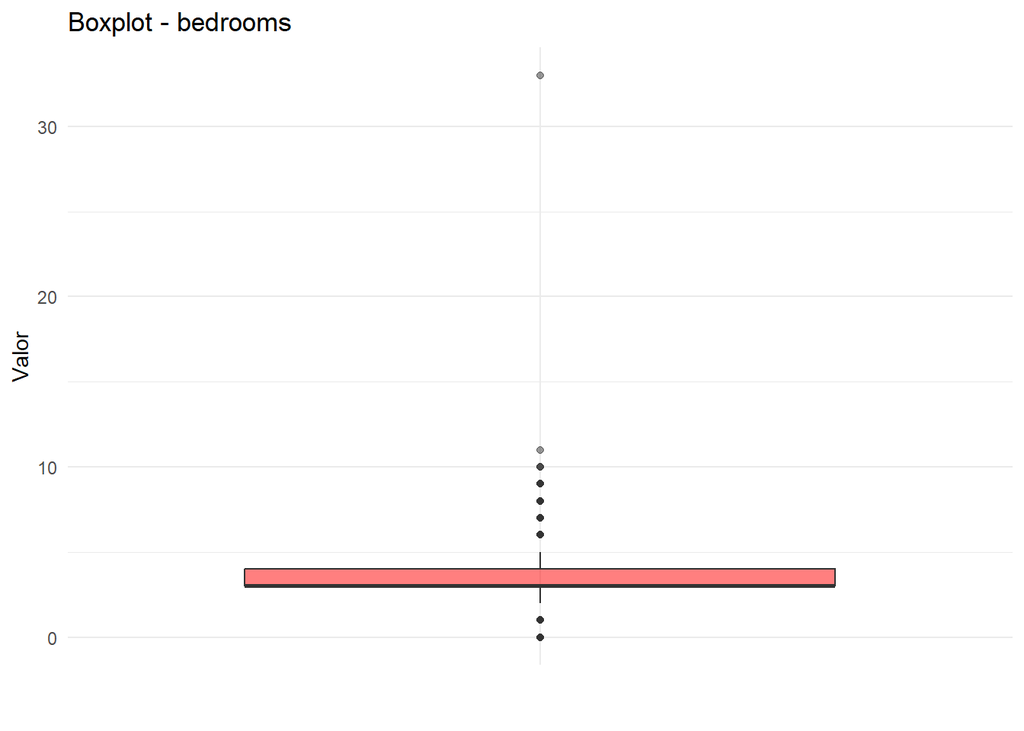

```r
boxplot_func <- function(y_variable) {
  ggplot(df, aes(x = "", y = {{y_variable}})) +
    geom_boxplot(fill = "red", alpha = 0.5) +
    labs(title = paste("Boxplot -", deparse(substitute(y_variable))),
         x = "",
         y = "Valor") +
    theme_minimal()
}

# Visualizando
boxplot_func(bedrooms)
```

Ánalisando o boxplot gerado, temos um imóvel com mais de 30 quartos dentro da base de dados. Esta observação será retirada da analise para não influenciar na modelagem.

```r
# Retirando observação com mais de 30 quartos
df <- df[df$bedrooms < 30, ]
```

Observando os valores outliers de preço.

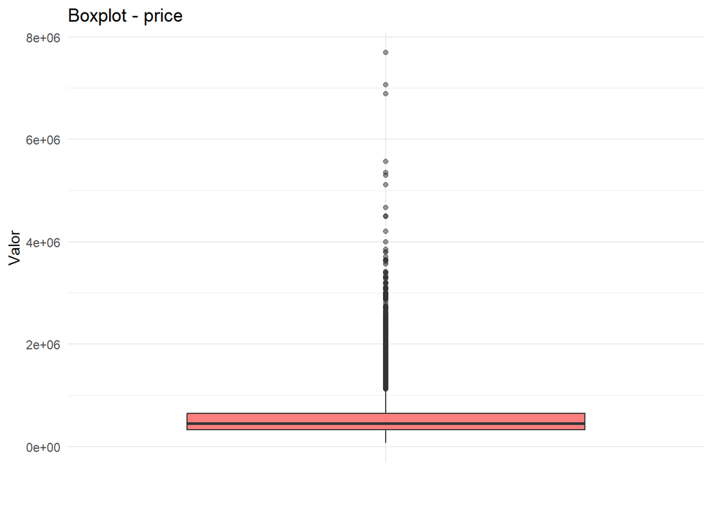

```r
boxplot_func(price)
```

De acordo com o boxplot gerado acima, iremos definir um corte para trabalhar apenas com apartamentos menores que 4 milhões.

```r
# Definindo corte
df <- df[df$price < 4000000, ]
```

### Tratamento da Preditora Quartos

Conforme analise exploratória, a relação entre o preço e o número de quartos não segue um padrão de linearidade, por conta disso, iremos criar uma categoria para esta coluna.

```r
# Transformando em categoria
df$categoria_quartos <- ifelse(df$bedrooms > 5, ">5", as.character(df$bedrooms))

# Retriando bedrooms
df$bedrooms <- NULL
```

### Ajustes finais

As ultimas alteração que será feita é retirar a coluna de id que não representa nenhuma informação relevante para a predição dos preços das casas e a coluna view que apenas representa quantas visistas a casa já recebeu, chegando assim no seguinte dataframe final:

```r
# Removendo coluna de id
df$id <- NULL
df$view <- NULL
df$price_sqft <- NULL

# Visualizando as 10 primeiras linhas
rmarkdown::paged_table(head(df))
```

|  | price | bathrooms | sqft_living | floors | waterfront | condition | grade | age | renovated | basement_percent | living_percent | grupo | categoria_quartos |
| --- | --- | --- | --- | --- | --- | --- | --- | --- | --- | --- | --- | --- | --- |
| 1 | 277500 | 2.25 | 1820 | 1 | 0 | 4 | 7 | 50 | 0 | 0.0000000 | 0.09284767 | D | 3 |
| 2 | 250000 | 2.00 | 1660 | 1 | 0 | 3 | 7 | 29 | 0 | 0.3915663 | 0.12686282 | D | 3 |
| 3 | 384000 | 2.75 | 3220 | 2 | 0 | 3 | 9 | 15 | 0 | 0.0000000 | 0.39460784 | D | 5 |
| 4 | 305000 | 1.75 | 2370 | 1 | 0 | 3 | 7 | 47 | 0 | 0.3839662 | 0.23372781 | D | 4 |
| 5 | 265000 | 1.50 | 1780 | 1 | 0 | 4 | 7 | 48 | 0 | 0.2865169 | 0.17457827 | D | 3 |
| 6 | 254000 | 2.00 | 2080 | 1 | 0 | 5 | 7 | 55 | 0 | 0.1634615 | 0.12905628 | D | 5 |

O dicionário de dados para o dataframe processado:

- price: Preço de venda;
- categoria_quartos: número de quartos em categoria;
- sqft_living: Tamanho de área hábitavel(construida);
- floors: número de andares;
- waterfront: Casas beira-mar;
- condition: Nota para a condição do imóvel;
- grade: nota geral atribuída à unidade habitacional, com base no sistema de classificação do Condado de King.
- age: idade do imóvel;
- renovated: (1) se o imóvel foi renovado em algum momento e (0) se não foi.
- basement_percent: Porcentagem de área construida que representa o porão;
- living_percent: Porcentagem de área de construida em relação ao tamanho total do terreno.

Salvando arquivo final para a ánalise exploratoria:

```r
write.csv(df, "data/df_pre_processamento.csv", row.names = FALSE)
```